# Data Wrangling:EDA

```python
import pandas as pd
import numpy as np
import seaborn as sns
import matplotlib.pyplot as plt
```

```python
file_path = 'C:/Users/angievasquez/Downloads/Border_Crossing_Entry_Data.csv'
```

```python
df = pd.read_csv('/Users/angievasquez/Downloads/Border_Crossing_Entry_Data.csv')
```

```python
print(df.head())
```

```
       Port Name    State  Port Code            Border      Date Measure
0           Roma    Texas       2310  US-Mexico Border  Dec 2023   Buses  \
1        Del Rio    Texas       2302  US-Mexico Border  Dec 2023  Trucks
2           Roma    Texas       2310  US-Mexico Border  Nov 2023  Trucks
3        Douglas  Arizona       2601  US-Mexico Border  Oct 2023   Buses
4  Beecher Falls  Vermont        206  US-Canada Border  Aug 2023  Trucks

   Value  Latitude  Longitude                          Point
0     46    26.404    -99.019   POINT (-99.018981 26.403928)
1   6552    29.327   -100.928  POINT (-100.927612 29.326784)
2   3753    26.404    -99.019   POINT (-99.018981 26.403928)
3     13    31.334   -109.560  POINT (-109.560344 31.334043)
4    422    45.013    -71.505   POINT (-71.505309 45.013411)
```

```python
print(df.shape)
```

```
(395638, 10)
```

```python
print(df.describe())
```

```
           Port Code         Value       Latitude      Longitude
count  395638.000000  3.956380e+05  395638.000000  395638.000000
mean     2446.496201  2.884933e+04      43.974092     -99.730139
std      1204.138442  1.495808e+05       8.151891      18.259105
min       101.000000  0.000000e+00      25.952000    -141.001000
25%      2304.000000  0.000000e+00      42.999000    -114.728000
50%      3012.000000  1.430000e+02      48.122000    -101.628000
75%      3401.000000  2.984000e+03      49.000000     -89.585000
max      3814.000000  4.447374e+06      62.615000     -66.980000
```

```python
df['Date'] = pd.to_datetime(df['Date'])
```

```python
crossings_by_date = df.groupby('Date')['Value'].sum()
```

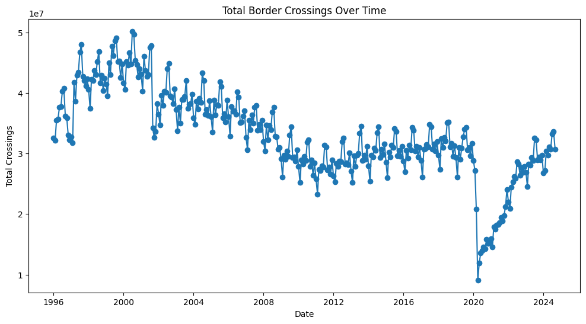

```python
plt.figure(figsize=(12, 6))
plt.plot(crossings_by_date.index, crossings_by_date.values, marker='o')
plt.title('Total Border Crossings Over Time')
plt.xlabel('Date')
plt.ylabel('Total Crossings')
plt.show()
```

```python
#Code help from google
```

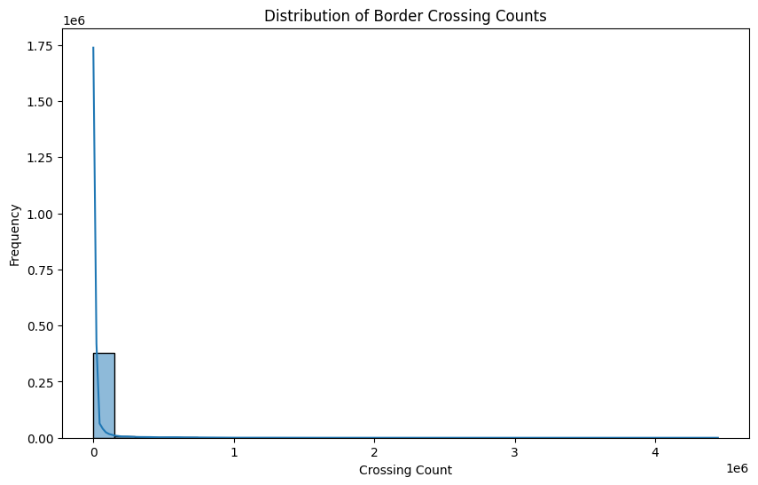

```python
plt.figure(figsize=(10, 6))
sns.histplot(df['Value'], bins=30, kde=True)
plt.title('Distribution of Border Crossing Counts')
plt.xlabel('Crossing Count')
plt.ylabel('Frequency')
plt.show()
```

```python
top_ports = df.groupby('Port Name')['Value'].sum().nlargest(10)
```

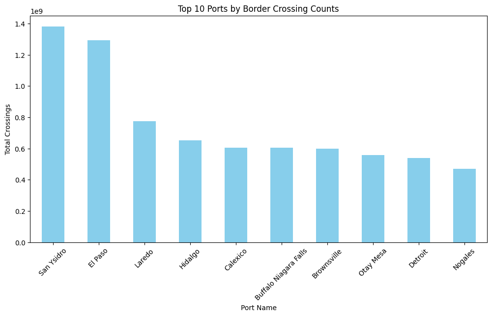

```python
plt.figure(figsize=(12, 6))
top_ports.plot(kind='bar', color='skyblue')
plt.title('Top 10 Ports by Border Crossing Counts')
plt.xlabel('Port Name')
plt.ylabel('Total Crossings')
plt.xticks(rotation=45)
plt.show()
```

What is in your data?

The data set from data.gov contains information on a summary of statistics of inbound crossings at the US Canada and US Mexico border at port level. This is categorized through information such as Data, Port Name, Border, Measure (ie. whether it is a personal vehicle, truck, bus, and so on). This provides some insight as to what are common ports, common types of transportation, providing a possible trend/pattern.

How will these data be useful for studying the phenomenon you're interested in?

Since this data set provides border crossings over the years, it can be analyzed to gauge potential patterns in seasonal increases in traffic. If there is an understanding of this trend, then it may be useful in predicting border corssing volumes based on this, as well as having the potential to go beyond to other factors.

What are the challenges you've resolved or expect to face in using them?

Data mat lack explanatory variables and other external factors, such as policy change or economic factors so it is not a for sure shot of predicting high accuracy. There may also be low counts of certain data points.